# 3. 함수 알아보기

- 함수는 def 예약어를 사용해서 정의한다.
- 함수는 이름을 지정한다. 이름없는 함수는 lambda 예약어를 사용한다.
- 함수는 정의하고 호출해서 사용한다.
- 이름없는 함수는 작성하면 바로 호출해서 사용할 수 있다.
- 함수 정의할 때 매개변수를 정의하고 함수를 호출할 때 이 매개변수와 매핑되는 인자를 값으로 전달한다.

## 3-1 함수란

- 입력 데이터를 받아서 출력 데이터를 만드는 매핑관계

```python
from IPython.display import Image
```

```python
Image("./이미지/함수이미지.gif")
```

[output not shown]

## 3-2 내장함수 알아보기

- 파이썬에서 기본으로 제공하는 함수

```python
type(print)
```

```
builtin_function_or_method
```

### 함수의 사용법을 help로 알아보기

- 함수나 클래스 등의 정의 내용을 확인할 때 사용한다

#### 출력함수 알아보기

```python
help(print)
```

```
Help on built-in function print in module builtins:

print(...)
    print(value, ..., sep=' ', end='\n', file=sys.stdout, flush=False)

    Prints the values to a stream, or to sys.stdout by default.
    Optional keyword arguments:
    file:  a file-like object (stream); defaults to the current sys.stdout.
    sep:   string inserted between values, default a space.
    end:   string appended after the last value, default a newline.
    flush: whether to forcibly flush the stream.
```

#### 객체 내의 원소 개수를 알아보기

```python
help(len)
```

```
Help on built-in function len in module builtins:

len(obj, /)
    Return the number of items in a container.
```

#### 출력함수는 출력하는 값들을 쉼표로 구분하면 출력이 됨

```python
print("출력1", 100, "출력2",200)
```

```
출력1 100 출력2 200
```

#### 출력할 때 구분자가 필요한 경우 sep 다음에 입력한다

```python
print("출력1", 100, "출력2",200, sep=',')
```

```
출력1,100,출력2,200
```

## 3-3 사용자 함수 정의

- 함수를 정의하는 것은 사용자가 만들어서 사용하는 함수이다

### 함수 정의

- 함수 예약어 def
- 함수 이름과 매개변수 지정
- 함수 내부에 수행할 로직 : 수행할 코드를 작성

```python
Image("./이미지/함수정의.gif")
```

[output not shown]

### 두개의 매개변수를 가지는 함수 add 를 작성한다.

- 결과값은 두 개의 매개변수를 더한 값을 반환한다

#### 문장을 작성할 때 주의 할점

- 파이썬은 문장 내에 문장을 작성할 때 구분을 띄어쓰기(indent)를 사용한다.
- 함수 내부의 문장은 def 함수명(매개변수) : 다음 문장에 작성할 때 4칸 띄어쓰기가 되어야 한다.

#### 띄어쓰기를 안하면 띄어쓰기 오류를 발생시킨다.

- 문장구분자는 콜론이므로 콜론 다음에 띄어쓰기가 없어서 오류를 발생

```python
def add(x,y) :
print(" 함수 add 가 실행")
    return x+y
```

```
  File "<ipython-input-35-7b4f1c375d0a>", line 2
    print(" 함수 add 가 실행")
        ^
IndentationError: expected an indented block
```

#### 정상적인 함수를 정의하기

```python
def add(x,y) :
    print(" 함수 add 가 실행")
    return x+y
```

```python
add
```

```
<function __main__.add(x, y)>
```

```python
add.__name__
```

```
'add'
```

## 3-4 사용자 함수 호출

- 사용자 함수의 이름과 호출연산자인 괄호 사이에 인자를 값으로 전달해서 실행한다.
- 실행결과는 return 내에 로직이 처리되어 반환한다.

### 함수가 정의되면 호출할 때 함수이름과 호출연산자(괄호) 사용

```python
Image("./이미지/함수정의및호출관계.gif")
```

[output not shown]

### 함수 이름과 매개변수에 매핑해서 인자를 전달

```python
add(10,10)
```

```
 함수 add 가 실행
```

```
20
```

### 두 개의 변수를 정의하고 이를 함수의 인자로 전달해서 실행한다

- 두 개의 매개변수를 정의하면 두 개의 인자를 전달한다.

```python
Image("./이미지/함수매개변수와인자매핑.gif")
```

[output not shown]

```python
x = 100
```

```python
y = 200
```

```python
add(x,y)
```

```
 함수 add 가 실행
```

```
300
```

## 3-5 익명함수 작성 및 호출

- lambda 예약어를 작성한다.
- 재사용을 하려면 변수에 할당한다
- 익명 함수는 return 문을 사용하지 못한다. 최종 값은 표현식을 사용해서 하나의 값을 자동으로 반환한다
- 매개변수는 lambda 와 콜론(:) 사이에 넣는다.
- 처리되는 것은 콜론(:) 다음에 표현식으로 처리한다

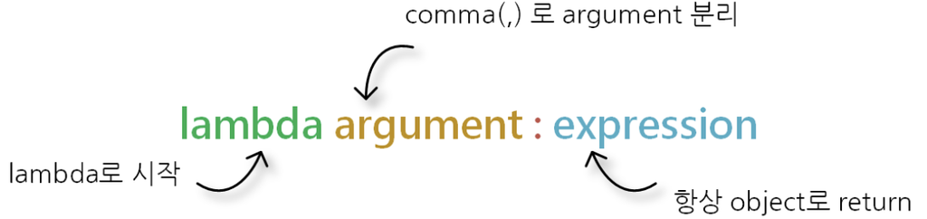

```python
Image("./이미지/람다함수정의.png")
```

### 일반함수와 람다함수를 비교

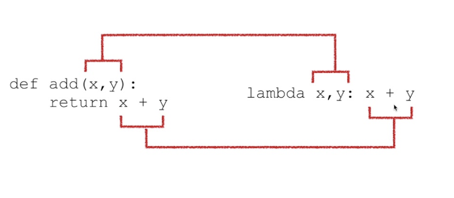

```python
Image("./이미지/일반함수와람다함수.png")
```

### 익명함수를 정의했지만 사용할 수 없다.

- 이름이 없어서 특정 변수에 저장되지 않는다.

```python
lambda x,y : x+y
```

```
<function __main__.<lambda>(x, y)>
```

### 익명함수를 변수에 할당하면 다시 사용할 수 있다.

- 재사용하는 함수는 사용자함수를 정의해서 사용한다

```python
add_ = lambda x,y : x+y
```

```python
add_
```

```
<function __main__.<lambda>(x, y)>
```

```python
add_(10,10)
```

```
20
```

### 익명함수는 작성한 후에 바로 호출해서 실행할 수 있다.

- 사용자 정의함수가 필요없는 경우 한번 작성해서 호출할 경우에 사용한다

```python
(lambda x,y : x+y)(10,10)
```

```
20
```

## 3-6 내부에 함수 및 재귀함수 정의하기

- 여러 개의 기능을 가진 하나의 함수를 정의할 때는 내부에 함수를 정의할 수 있다.
- 내부 함수를 정의할 때도 띄어쓰기에 주의해야 한다. 함수 내부에 정의된 문장도 띄어쓰기를 해야한다

```python
Image("./이미지/중첩함수와재귀함수.gif")
```

[output not shown]

### 중첩함수(내부함수) 정의하기

- 함수 내부에 함수를 정의해서 내부함수를 실행한 후에 반환한다

```python
def add_mul(x,y) :
    print('add_mul 실행 ')
    def mul() :
        print('mul 실행')
        return x* y
    return x+y + mul()
```

#### 함수를 호출하면 내부 함수 정의된 결과도 실행되어 결과를 반환한다

```python
add_mul(10,10)
```

```
add_mul 실행
mul 실행
```

```
120
```

### 재귀함수

- 자기 함수를 내부에서 다시 호출해서 사용하는 함수
- 재귀함수 작성할 때 마지막 처리 로직을 반드시 정해야 한다. 없을 경우 무한 반복을 처리한다.
- 재귀함수 호출은 return 문에 작성한다. 인자로 전달하는 값을 항상 줄여서 전달한다.

```python
def fac(num) :
    if num == 0 : # 마지막 호출할 경우 끝으로 처리해서 빠져나가는 로직
        return 1
    return fac(num-1) * num
```

```python
fac(5)
```

```
120
```

### 수학 함수 모듈을 사용해서 검증한다

```python
import math
```

```python
math.factorial(5)
```

```
120
```

## 3-7. 네임스페이스 참조 규칙

- 프로그램언어는 내장 영역이 제일 상위에 있다.
- 모듈울 작성하면 전역 영역이 생긴다. 모듈에서는 내장 영역을 참조할 수 있다.
- 함수를 정의하면 지역이 생긴다. 함수 내부에 내부함수를 정의하면 내부함수 내부도 자신의 지역영역이다.

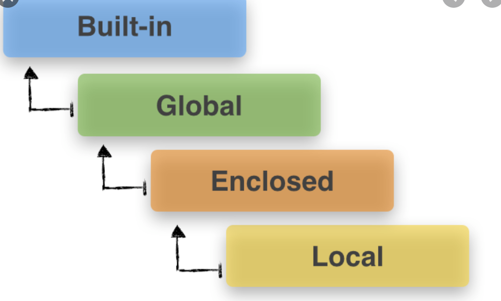

```python
Image("./이미지/네임스페이스참조규칙.png")
```

### 모듈에 정의된 변수는 전역(global ) 영역이고 함수 내의 변수는 지역(local) 영역

- 함수를 실행하면 내부변수부터 참조

```python
var = 100

def func() :
    var = 200
    return var
```

```python
func()
```

```
200
```

### 함수 내부에서 전역변수를 사용할 때는 반드시 global 예약어를 지정해야함

```python
def func_() :
    global var
    return var
```

```python
func_()
```

```
100
```

### 함수 내부에 함수를 정의하면 내부함수는 외부함수의 모든 변수를 공유해서 사용함

```python
def outer() :
    var = 300
    def inner() :
        return var
    return inner()
```

```python
outer()
```

```
300
```

### 내부함수에서 외부함수의 변수를 지정해서 사용할 경우

```python
def outer_() :
    var_ = 500
    def inner_() :
        nonlocal var_
        return var_
    return inner_()
```

```python
outer_()
```

```
500
```